# Renforcer les preuves de performance du système de santé au Burkina Faso

Author

O. Billa

Published

April 30, 2025

# 1 Objectif /Objective

Ce projet vise à produire des estimations fiables et actualisées de la mortalité des enfants de moins de 5 ans au Burkina Faso, en combinant différentes sources de données et méthodes d’estimation

## 1.1 2. Données utilisées pour l’estimation de la mortalité infantile

Sources de données utilisées dans l’analyse de la mortalité au Burkina Faso

| **Catégorie** | **Source de données** | **Années couvertes** | **Méthode** | **Couverture géographique** |
| --- | --- | --- | --- | --- |
| **Enquêtes** | DHS | 2003, 2010, 2021 | Directe | Nationale & régionale |
|  | MICS | 2006 | Indirecte | Nationale & régionale |
|  | MIS | 2014, 2017 | Indirecte | Nationale & régionale |
| **Recensements** *(en attente de données)* | Recensement général de la population | 2006, 2019 | - | - |

## 1.2 3. Methodologie

## 1.3 3.1. Estimation de la mortalite par la methode indirecte :

La méthode de Brass permet d’estimer la mortalité des enfants à partir de données sommaires de naissances (Summary Birth History – SBH). Elle repose sur l’utilisation de tables types de mortalité et de fécondité, et sur l’exploitation des réponses de femmes en âge de procréer (15–49 ans) concernant :

- le nombre total d’enfants nés (CEB : v201)
- le nombre d’enfants encore en vie (v202)
- la répartition des femmes par groupe d’âge (v013) ou selon la durée de mariage

Ces informations permettent d’estimer la probabilité qu’un enfant meure avant un âge donné (noté *nq0*), pour différentes périodes antérieures à l’enquête.

### 1.3.1 Hypothèses de la méthode de Brass

- La fécondité et la mortalité suivent les schémas représentés dans des tables types.
- La mortalité des enfants est indépendante de la survie ou de la migration de leurs mères.
- La mortalité évolue progressivement et dans une seule direction au fil du temps.
- Le nombre moyen d’enfants jamais nés reflète les comportements de fécondité des cohortes passées.

### 1.3.2 3.1.1 Étapes de calcul

**Étape 1 – Proportion d’enfants décédés**  
PDₓ = (CEB - CS) / CEB

**Étape 2 – Parité moyenne**  
Px = Σ(CEBᵢ) / Nx

**Étape 3 – Choix de la table de mortalité**  
(Coale-Demeny ou modèles ONU selon le contexte) : le modele Coale-Demeny Ouest est convenable au pays du sahel

**Étape 4 – Âge moyen de maternité (m̄)**  
Calculé à partir des taux de fécondité par âge (5fₓ)

**Étape 5 – Probabilités de décès estimées**  
Utilisation de coefficients tirés des tables modèles pour convertir PDₓ en nq₀ selon le groupe d’âge.

**Étape 6 – Date de référence estimée**  
t(x) = e + f·(P15/P20) + g·(P20/P25)

**Étape 7 – Conversion logit de nq₀ en q₁ ou q₅**  
1. Y(n) = 0.5 × ln(nq₀ / (1 – nq₀))  
2. α = Y(n) – Y⁽ˢ⁾(n)  
3. q₅ = exp(2(α + Y⁽ˢ⁾(5))) / [1 + exp(2(α + Y⁽ˢ⁾(5)))]

### 1.3.3 Tableau : Estimations indirectes de la mortalité (MIS 2017)

| Groupe d’âge | Femmes | Enfants nés | Enfants décédés | Parité moyenne (π) | Proportion décédés (dᵢ) | Coefficient kᵢ | q(x) | Date de référence | Année estimée | q(5) |
| --- | --- | --- | --- | --- | --- | --- | --- | --- | --- | --- |
| 15–19 | 1280 | 1768 | 156 | 1.38 | 0.088 | 1.037 | 0.091 | 2.41 | 2014.6 | 0.107 |
| 20–24 | 1326 | 3811 | 376 | 2.87 | 0.099 | 0.995 | 0.098 | 4.32 | 2012.7 | 0.106 |
| 25–29 | 1192 | 5032 | 543 | 4.22 | 0.108 | 1.007 | 0.109 | 6.59 | 2010.4 | 0.109 |
| 30–34 | 1106 | 5838 | 711 | 5.28 | 0.122 | 1.026 | 0.125 | 9.09 | 2007.9 | 0.114 |
| 35–39 | 676 | 4205 | 618 | 6.22 | 0.147 | 1.035 | 0.149 | 11.78 | 2005.2 | 0.128 |
| 40–44 | 541 | 3602 | 565 | 6.66 | 0.157 | 1.006 | 0.158 | 14.70 | 2002.3 | 0.125 |

## 1.4 3.2. Estimation de la mortalite par la methode directe :

La méthode directe consiste à reconstruire des taux de mortalité en utilisant les dates de naissance et, si applicable, de décès des enfants nés des femmes enquêtées. Cette méthode repose sur les données complètes de naissances vivantes enregistrées dans les enquêtes démographiques de type DHS.

Pour ce faire, nous avons utilisé le package `DHS.rates` de R qui permet d’estimer les probabilités de décès (comme q1 et q5) sur des périodes définies avant l’enquête. Dans notre approche, nous avons opté pour une **période de référence de 5 ans** suivant la recommandation standard, en prenant soin d’éviter le **chevauchement des fenêtres temporelles**, afin de garantir l’indépendance des estimations successives.

Ce choix permet d’obtenir des estimations cohérentes et comparables d’une enquête à une autre.

## 1.5

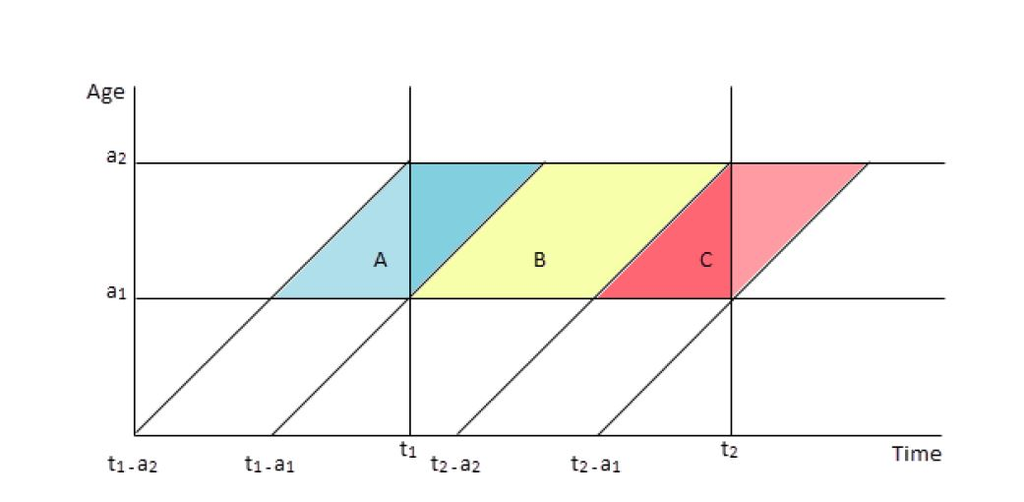

## 1.6 3.3. Modelisation de la tendance par regression beta :

Pour produire une courbe de tendance robuste de la mortalité des moins de 5 ans, nous avons adopté une approche de modélisation utilisant la régression bêta avec un lien logit. Cette approche est particulièrement adaptée aux données de proportion comme les taux de mortalité, qui sont naturellement contraints entre 0 et 1.

### 1.6.1 3.3.1 Specification du modele

Nous avons d’abord transformé nos taux de mortalité (qui sont exprimés pour 1000 naissances vivantes) en proportions, en appliquant une correction pour éviter les valeurs extrêmes 0 et 1 qui ne sont pas admissibles dans la distribution bêta :

$$U5MR_{prop} = \frac{U5MR}{1000} \cdot \frac{n-1}{n} + \frac{0.5}{n}$$

Où : - $U5MR$ représente le taux de mortalité des moins de 5 ans (pour 1000 naissances vivantes) - $U5MR_{prop}$ est la proportion transformée utilisée dans le modèle - $n$ est le nombre total d’observations

Notre modèle utilise un modèle additif généralisé (GAM) avec une distribution bêta et un lien logit pour modéliser la relation non-linéaire entre le taux de mortalité et le temps :

$$\text{logit}(E(U5MR_{prop})) = s(\text{année})$$

Où : - $s(\text{année})$ est une fonction de lissage de type spline de régression cubique avec un degré de complexité maximal fixé à 10 nœuds - La fonction logit est définie comme $\text{logit}(p) = \ln\left(\frac{p}{1-p}\right)$

Cette spécification permet de modéliser adéquatement la nature bornée des taux de mortalité tout en offrant la flexibilité nécessaire pour représenter des tendances non-linéaires. L’utilisation d’une spline de régression cubique avec un nombre maximum de nœuds fixé à 10 assure un équilibre optimal entre fidélité aux données et lissage de la courbe.

### 1.6.2 3.3.3 Prédictions et intervalles de confiance

À partir du modèle ajusté, nous avons généré des prédictions pour chaque année de 1990 à 2023 (par intervalles de 2 ans), accompagnées d’intervalles de confiance à 95%. Les prédictions, obtenues sur l’échelle logit, ont ensuite été reconverties en taux de mortalité pour 1000 naissances vivantes à l’aide de la transformation inverse :

$U5MR_{est} = \log^{-1}(\text{fit}) \times 1000$

# 2 4. Outpouts

## 2.1 4.1. National

### 2.1.1 4.1.1. Courbes d’estimation de la mortalite par sources de donnees

#### 2.1.1.1 a. MIS 2017

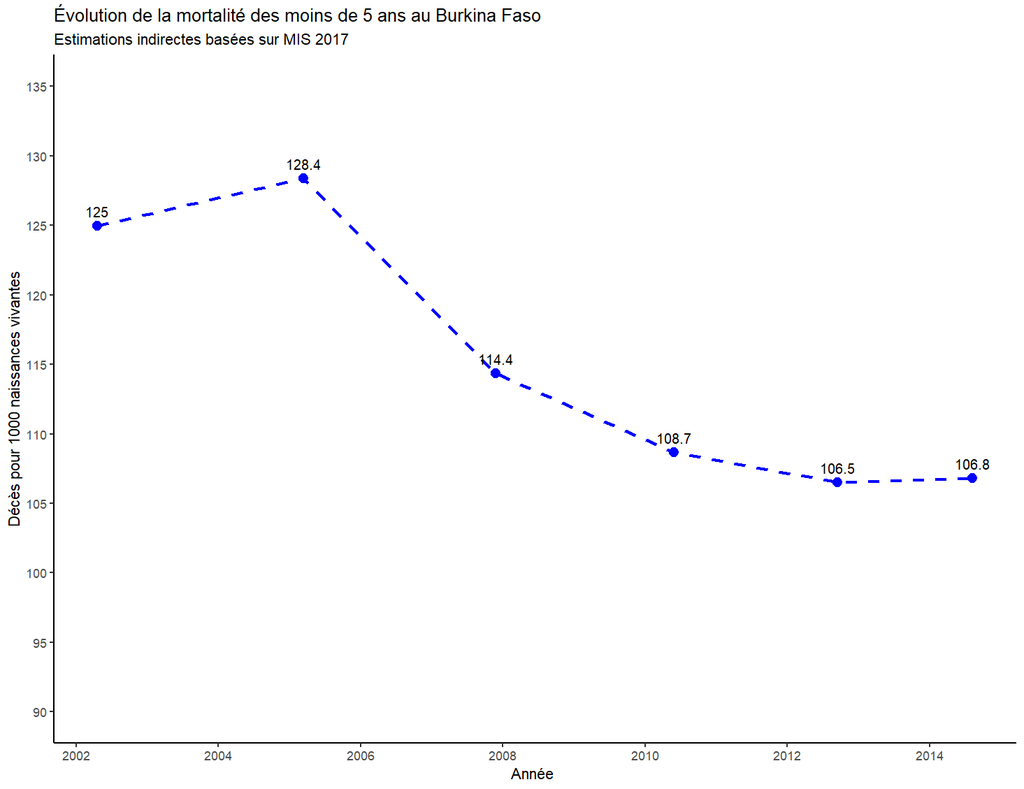

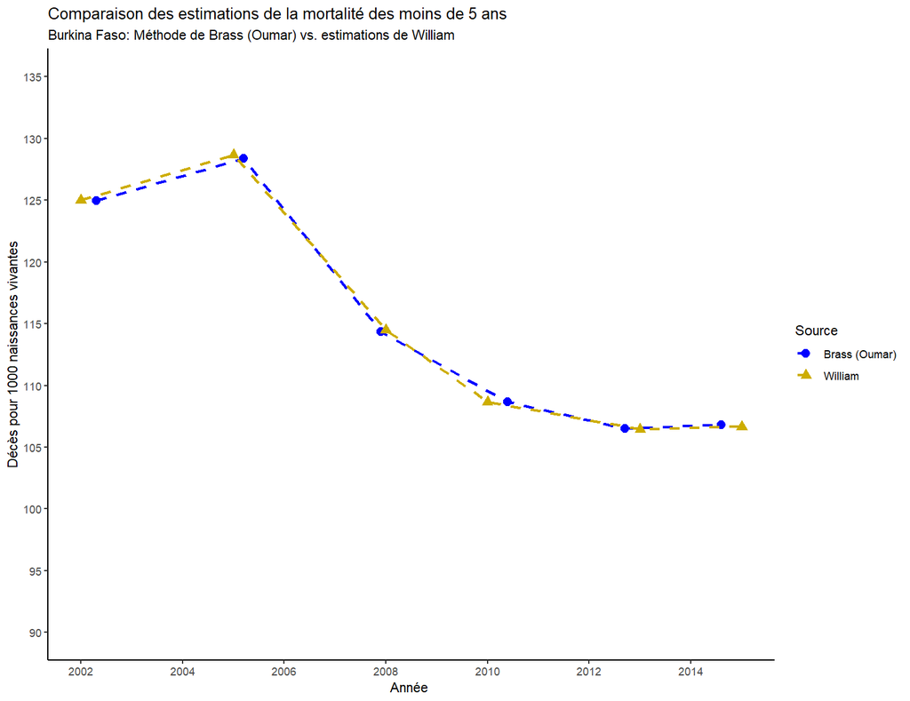

#### 2.1.1.2 b. MIS 2014

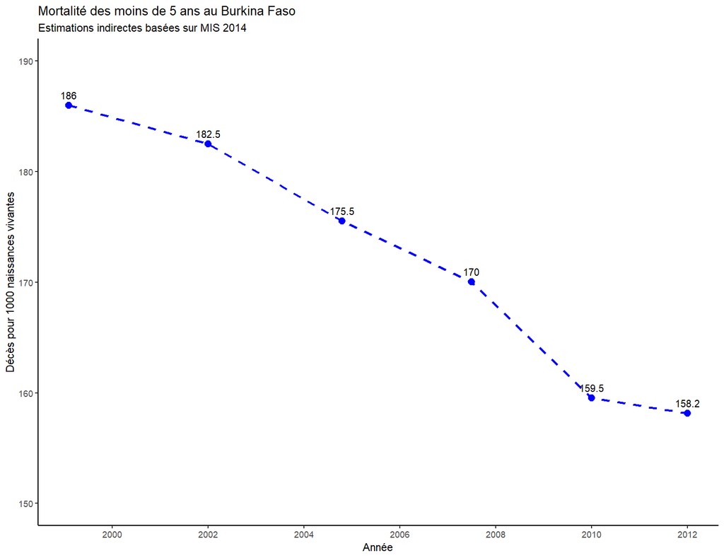

#### 2.1.1.3 **c. DHS 2021**

#### 2.1.1.4

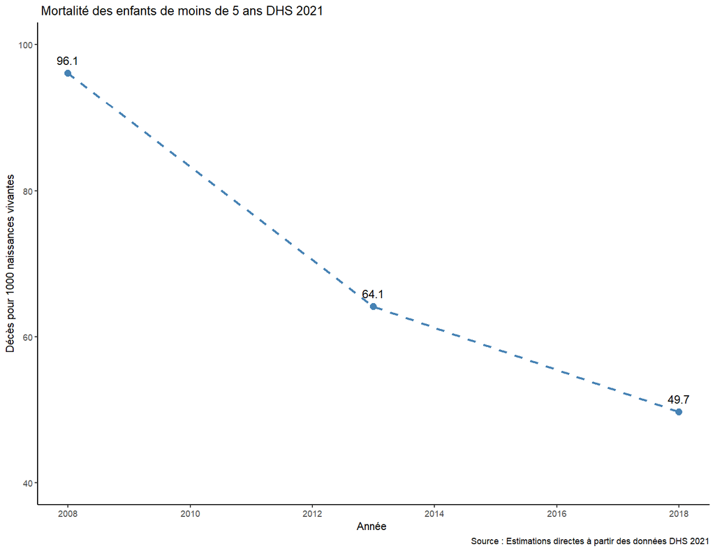

### 2.1.2 4.1.1. Courbes d’estimation de la mortalite par sources de donnees

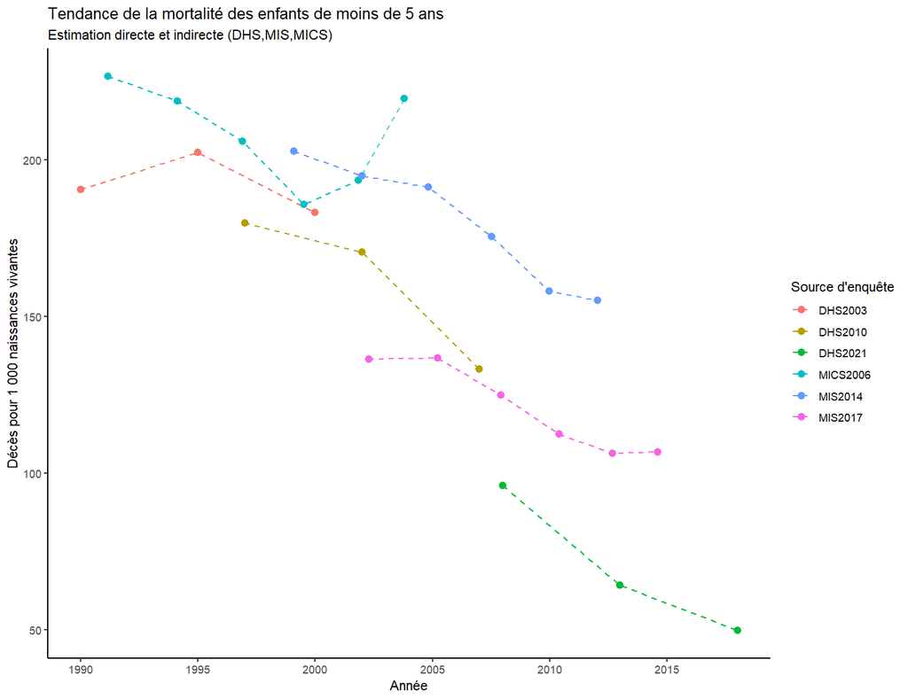

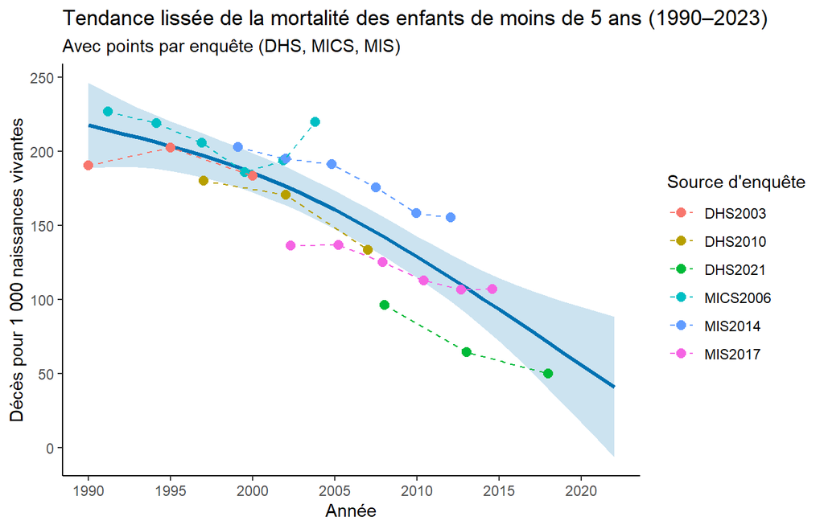

# 3 comparaison courbes tendance lissee

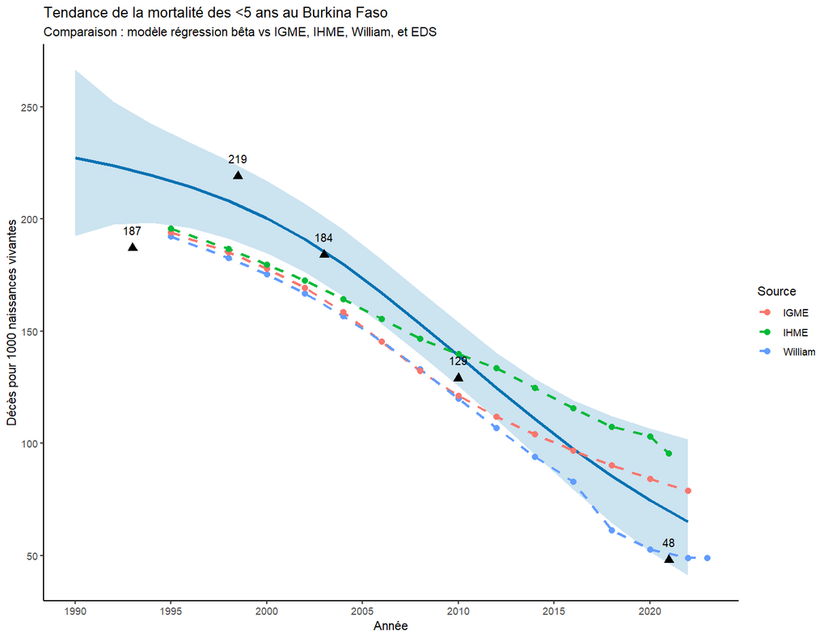

## 3.1 4.2. Estimation regionale

### 3.1.1 4.2.1. Region du Boucle de Mouhoun

4.2.1.1. mortalite DHS 2021

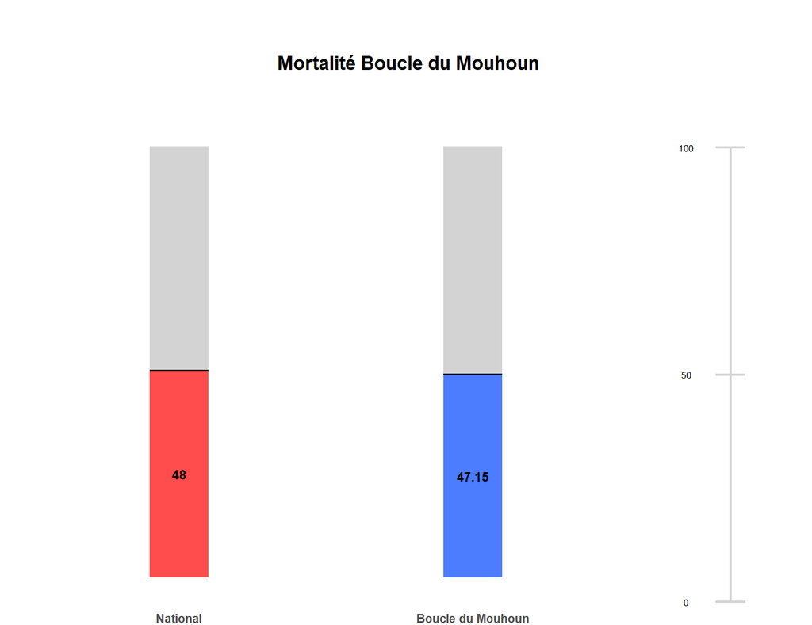

4.2.2. Estimation mortalite q5

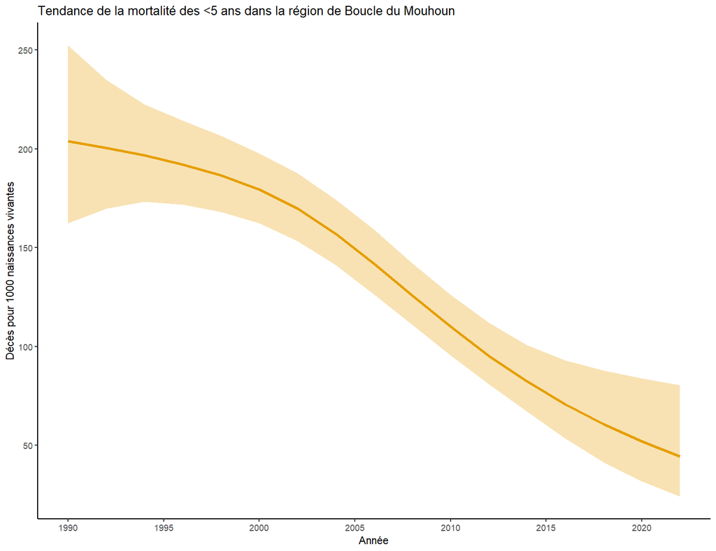

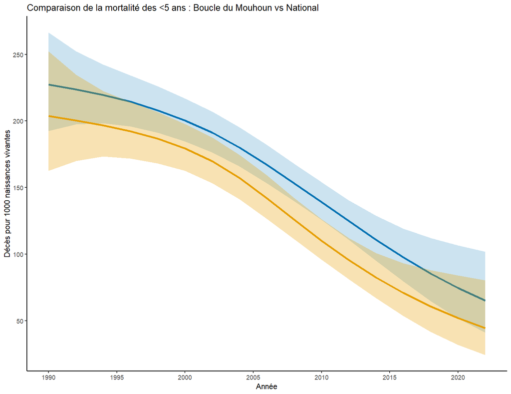

## 3.2 Heatmap des differentes region ( va venir plus bas apres la desc reg)

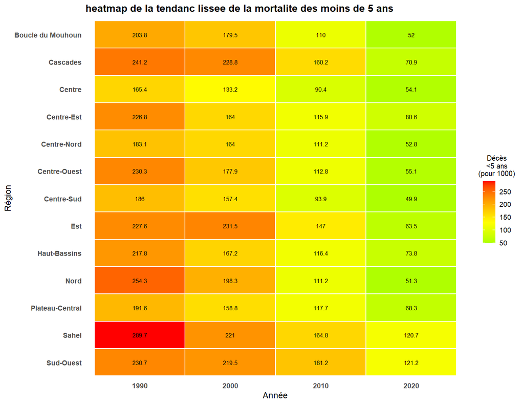